# Ordinal Logistic Regression in R

## Proportional Odds

Recall: odds = p/(1 -p)

Predicted probability of Improved = None on Treatment is 0.3062450. The odds are calculated as 0.3062450/(1 - 0.3062450)

```r
p2/(1 - p2)
```

```
None|Some
 0.441431
```

Predicted probability of Improved = None on Placebo is 0.6791592. The odds are calculated as 0.6791592/(1 - 0.6791592)

```r
p1/(1 - p1)
```

```
None|Some
 2.116811
```

The odds ratio for those two odds are

```r
(p2/(1 - p2))/
(p1/(1 - p1))
```

```
None|Some
0.2085359
```

If we take the log of that we get the model coefficient for Treatment with a change in sign. (We explain why that is shortly.)

```r
log((p2/(1 - p2))/
(p1/(1 - p1)))
```

```
None|Some
-1.567644
```

Now let’s do the same calculation for the Some or lower cumulative probabilities:

```r
# p4 = P(Some or lower) if Treated
# p3 = P(Some or lower) if Placebo
log((p4/(1 - p4))/
(p3/(1 - p3)))
```

```
Some|Marked
  -1.567644
```

Let’s look at the coefficient from the model again.

```r
coef(m1)
```

```
TreatmentTreated
        1.567644
```

This is identical to what we derived above, but with a change in sign. `polr()` multiplies the coefficients in the summary output by -1 so when you exponentiate and take the odds ratio, *higher levels of predictors correspond to the response falling in the higher end of the ordinal scale*.

```r
exp(coef(m1))
```

```
TreatmentTreated
        4.795338
```

Interpretation: the estimated odds that a Treated subject’s response has higher improvement is about 4.8 times the odds that a Placebo subject’s response has higher improvement

## Summary output and confidence intervals

Let’s look again at the output summary:

```r
summary(m1)
```

```
Re-fitting to get Hessian
```

```
Call:
polr(formula = Improved ~ Treatment, data = Arthritis)

Coefficients:
                 Value Std. Error t value
TreatmentTreated 1.568     0.4441    3.53

Intercepts:
            Value  Std. Error t value
None|Some   0.7499 0.3210     2.3363
Some|Marked 1.5499 0.3559     4.3553

Residual Deviance: 156.606
AIC: 162.606
```

The Standard Errors quantify the uncertainty in the estimated intercepts and coefficients. The t values are the ratios of values to standard errors. T values larger than 2 are good evidence that the coefficient is in the *right direction*.

To understand the uncertainty of the magnitude of the coefficient, we can calculate 95% confidence intervals using `confint()`:

```r
exp(confint(m1))
```

```
Re-fitting to get Hessian
```

```
    2.5 %    97.5 %
 2.044824 11.739936
```

The estimated odds that a Treated subject’s response has higher improvement is at least 2 times the odds that a Placebo subject’s response has higher improvement, perhaps as high as 11 times.

## Using predict() with fitted models

Earlier we made predictions “by hand” for teaching purposes with intercept and coefficient values. In practice we would likely use `predict()` to get fitted probabilities. Using the `newdata` argument we can specify what we want to make predictions for. The default is to predict the class, or level, for the given predictors. (`type = "class"`)

The Placebo group is predicted to experience No improvement while the Treated groups is expected to experience Marked improvement.

```r
predict(m1, newdata = data.frame(Treatment = c("Placebo", "Treated")),
        type = "class")
```

```
[1] None   Marked
Levels: None Some Marked
```

Changing `type = "probs` returns expected probabilities for each class.

```r
predict(m1, newdata = data.frame(Treatment = c("Placebo", "Treated")),
        type = "probs")
```

```
       None      Some    Marked
1 0.6791592 0.1457365 0.1751042
2 0.3062450 0.1893130 0.5044420
```

Notice these are NOT cumulative probabilities. These are expected probabilities for each level. They sum to 1. We see that `type = "class"` setting is simply picking the category with the highest probability.

If we wanted cumulative probabilities, we need to use `cumsum()`

```r
predict(m1, newdata = data.frame(Treatment = c("Placebo", "Treated")),
        type = "probs") |>
  apply(1,cumsum) |>
  t()
```

```
       None      Some Marked
1 0.6791592 0.8248958      1
2 0.3062450 0.4955580      1
```

## Visualizing the model

```
Re-fitting to get Hessian
```

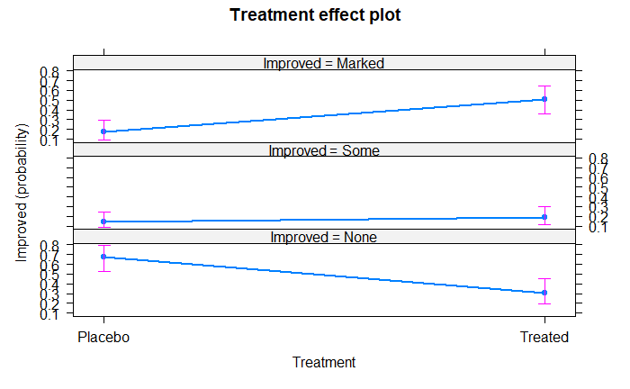

```r
Effect(m1, focal.predictors = "Treatment") |> plot()
```

## CODE ALONG 1

- Build an ordinal regression model with Treatment and Age. Call it `m2`. Include `Hess = TRUE` in `polr()`
- Interpret the Treatment and Age coefficients

```r
summary(m2)
```

```
Call:
polr(formula = Improved ~ Treatment + Age, data = Arthritis,
    Hess = TRUE)

Coefficients:
                   Value Std. Error t value
TreatmentTreated 1.55599    0.45333   3.432
Age              0.04085    0.01806   2.262

Intercepts:
            Value  Std. Error t value
None|Some   2.9341 1.0400     2.8212
Some|Marked 3.7822 1.0754     3.5171

Residual Deviance: 151.1459
AIC: 159.1459
```

```r
exp(coef(m2))
```

```
TreatmentTreated              Age
        4.739769         1.041694
```

Interpretation: The estimated odds that a subject has higher improvement increase about 4% for each 1 year increase in age, holding all other variables constant.

## References

- David Meyer, Achim Zeileis, and Kurt Hornik (2022). vcd: Visualizing Categorical Data. R package version 1.4-10.
- G. Koch & S. Edwards (1988), Clinical efficiency trials with categorical data. In K. E. Peace (ed.), Biopharmaceutical Statistics for Drug Development, 403–451. Marcel Dekker, New York.
- Venables, W. N. & Ripley, B. D. (2002) Modern Applied Statistics with S. Fourth Edition. Springer, New York. ISBN 0-387-95457-0